# Fantasy Baseball Head-to-Head Models - SVM

## Introduction

This project explores weekly matchup data from my fantasy baseball league for the 2011-2019 seasons.  
Parts of this analysis are motivated by [Peadar Coyle's](https://docs.pymc.io/pymc-examples/examples/case_studies/rugby_analytics.html) Rugby Analysis case study, and [PyMC3's GLM: Logistic Regression](https://docs.pymc.io/pymc-examples/examples/generalized_linear_models/GLM-logistic.html) example.

The data was collected using the [Yahoo Fantasy Baseball](https://developer.yahoo.com/fantasysports/guide/) API and is available in a local PostgreSQL database.

The 2016-2019 seasons were chosen because the categories were consistent throughout those four seasons.  
They consist of the following counting (aggregate) categories as identified in the data:

> **Batting**: `b_BB`: Walks; `b_HR`: Home Runs; `b_K`: Strikeouts; `b_NSB`: Net Stolen Bases; `b_R`: Runs; `b_RBI`: Runs Batted In.  
> **Pitching**: `p_BB`: Walks; `p_IP`: Innings Pitched; `p_K`: Strikeouts; `p_L`: Losses; `p_NSVH`: Net Saves and Holds; `p_QS`: Quality Starts; `p_W`: Wins.

The rest are rate categories:

> **Batting**: `b_AVGr`: Batting Average; `b_OBPr`: On-Base Percentage; `b_SLGr`: Slugging Percentage.  
> **Pitching**: `p_ERAr`: Earned-run Average; `p_WHIPr`: Walks plus Hits per Innings Pitched.

Despite this, Yahoo's API includes a "weekly winning team" category, and for the sake of exploring the data and Bayesian approaches, the concept of a team winning the weekly matchup will be used to develop exploratory models.

### Library Imports

```python
# Utilities
import os
import warnings
warnings.filterwarnings("ignore")
from pathlib import Path

# Plotting
import matplotlib as mpl
import matplotlib.pyplot as plt
import matplotlib.cm as cm
import seaborn as sns

# Data-handling
import numpy as np
import pandas as pd

# Modeling
from sklearn import svm
from sklearn.preprocessing import StandardScaler
from sklearn.model_selection import StratifiedShuffleSplit
from sklearn.model_selection import GridSearchCV
from sklearn.model_selection import train_test_split
from sklearn.metrics import confusion_matrix

%matplotlib inline
mpl.style.use('ggplot')
```

## Data Import

```python
# 2014 - 2019
try:
    from league.config import DATA_DIRECTORY, LEAGUE_DATA_DIRECTORY
    league_directory = LEAGUE_DATA_DIRECTORY
    data_directory = DATA_DIRECTORY
    data = pd.read_csv(os.path.join(data_directory, "full_data.csv"))
except FileNotFoundError:
    data = pd.read_csv("./full_data.csv")

# Separate current season to hold out to test models
current_season = data['season'] == 2021
current_season

data_2021 = data.loc[current_season]

data = data.loc[data['season'] != 2021].reset_index(drop=True)

data.sample(3)
```

|  | season | week | n_days | team_id | matchup | matchup_id | category | value | won_category | won_week |
| --- | --- | --- | --- | --- | --- | --- | --- | --- | --- | --- |
| 19638 | 2018 | 11 | 7 | 10 | 2018_11_05 | A | b_R | 39.0 | 1.0 | True |
| 16545 | 2017 | 22 | 7 | 9 | 2017_22_01 | A | b_BB | 20.0 | 0.0 | True |
| 21163 | 2018 | 17 | 7 | 12 | 2018_17_05 | A | p_K | 49.0 | 1.0 | False |

Model AVG, OBP, SLG, HR  
Model WHIP, ERA, QS

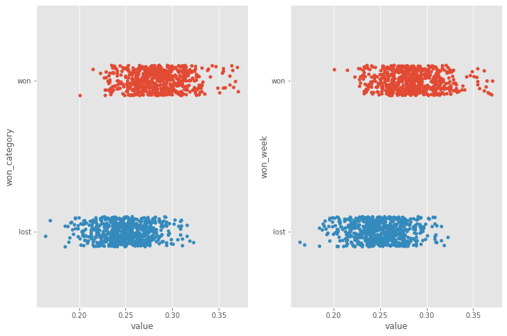

```python
# b_AVGr
plt_df = data.copy()
plt_df['won_category'] = plt_df['won_category'].replace({0: 'lost', 1: 'won'})
plt_df['won_week'] = plt_df['won_category'].replace({False: 'lost', True: 'won'})

fig, axs = plt.subplots(1, 2, figsize=(12, 8))

df = plt_df.loc[data['category'] == 'b_AVGr', ['category', 'value', 'won_category', 'won_week']]
sns.stripplot(ax=axs[0], x= df['value'], y = df['won_category'])
sns.stripplot(ax=axs[1], x= df['value'], y = df['won_week'])
```

# Models

##### AVG

```python
def train_model(df, category, C_gamma=None):

    '''
    df: data used to fit model
    category: category to model
    C_gamma: Optional 'C' and 'gamma' values for the svm model
        The train_svc function will choose the optimal parameters, but enter values here to test further
    '''

    # filter dataset by category
    category_mask = df['category'] == category

    # stack and unstack
    df = pd.DataFrame(df.loc[category_mask, ['matchup', 'value', 'won_week', 'matchup_id']].groupby(['matchup', 'matchup_id'])['value', 'won_week'].sum()).unstack()

    print(f'\nStacked and filtered dataset:\n {df}\n')

    X = df[['value']].values
    y = df[['won_week']].values[:, 0]

    X_train, X_test, y_train, y_test = train_test_split(X, y, random_state=42)
    sns.scatterplot(x = X_train[:, 0], y = X_train[:, 1], hue = y_train)

    def prediction(fitted_model, Xtest, ytest):
        y_pred = fitted_model.predict(Xtest)

        print(f'\nScore:\n{fitted_model.score(Xtest, ytest)}\n')

        print(f'\nConfusion matrix:\n{confusion_matrix(ytest,y_pred)}\n')

    def train_svc(Xtrain, ytrain):

        # Scale -> Update this with other project.ipynb scaling

        # It is usually a good idea to scale the data for SVM training.
        # We are cheating a bit in this example in scaling all of the data,
        # instead of fitting the transformation on the training set and
        # just applying it on the test set.

        # scaler = StandardScaler()
        # X_train = scaler.fit_transform(X_train)

        # Train classifiers
        #
        # For an initial search, a logarithmic grid with basis
        # 10 is often helpful. Using a basis of 2, a finer
        # tuning can be achieved but at a much higher cost.
        C_range = np.logspace(-2, 4, 7)
        gamma_range = np.logspace(-9, 2, 12)
        param_grid = dict(gamma = gamma_range, C=C_range)
        cv = StratifiedShuffleSplit(n_splits=6, test_size=0.2, random_state=42)
        grid_cv = GridSearchCV(svm.SVC(), param_grid=param_grid, cv=cv, verbose=1)
        grid_cv.fit(Xtrain, ytrain)

        print("The best parameters are %s with a score of %0.2f"
              % (grid_cv.best_params_, grid_cv.best_score_))

        return grid_cv

    def plot_svc(model, Xtrain, ytrain):

        print(f'\nModel:\n{model}\n')

        model.fit(Xtrain, ytrain)

        plt.figure(figsize=(12, 6))

        plt.scatter(Xtrain[:, 0], Xtrain[:, 1], c=ytrain, s=30, cmap=plt.cm.Paired)
        ax = plt.gca()
        xlim = ax.get_xlim()
        ylim = ax.get_ylim()

        # create grid to evaluate model
        xx = np.linspace(xlim[0], xlim[1], 30)
        yy = np.linspace(ylim[0], ylim[1], 30)
        YY, XX = np.meshgrid(yy, xx)
        xy = np.vstack([XX.ravel(), YY.ravel()]).T
        Z = model.decision_function(xy).reshape(XX.shape)

        # plot decision boundary and margins
        ax.contour(XX, YY, Z, colors='k', levels=[-1, 0, 1], alpha=0.5,
                   linestyles=['--', '-', '--'])
        # plot support vectors
        ax.scatter(model.support_vectors_[:, 0], model.support_vectors_[:, 1], s=100,
                   linewidth=1, facecolors='none', edgecolors='k')
        plt.show()

        return model

    if C_gamma is None:
        grid = train_svc(X_train, y_train)
        clf = plot_svc(svm.SVC(C=grid.best_params_['C'], gamma=grid.best_params_['gamma']), X_train, y_train)
        print(prediction(clf, X_test, y_test))
        return clf
    else:
        for i, cg in enumerate(C_gamma.items()):
            print(f'\nC: {cg[0][i]}\n')
            print(f'\ngamma: {cg[1][i]}\n')
            grid = train_svc(X_train, y_train)
            clf = plot_svc(svm.SVC(C=C_gamma['C'][i], gamma=C_gamma['gamma'][i]), X_train, y_train)
            print(prediction(clf, X_test, y_test))
            if len(C_gamma['C']) == 1:
                return clf
```

```python
def test_model(df, category, model):

    '''
    df: data used to test model
    category: category to model
    model: existing model
    '''

    # filter dataset by category
    category_mask = df['category'] == category

    # stack and unstack
    df = pd.DataFrame(df.loc[category_mask, ['matchup', 'value', 'won_week', 'matchup_id']].groupby(['matchup', 'matchup_id'])['value', 'won_week'].sum()).unstack()

    print(f'\nStacked and filtered dataset:\n {df}\n')

    X = df[['value']].values
    y = df[['won_week']].values[:, 0]

    y_pred = model.predict(X)

    print(f'\nScore:\n{model.score(X, y)}\n')

    print(f'\nConfusion matrix:\n{confusion_matrix(y, y_pred)}\n')
```

```
Stacked and filtered dataset:
             value        won_week
matchup_id      A      H        A  H
matchup
2016_01_00  0.286  0.283        1  0
2016_01_01  0.247  0.286        1  0
2016_01_02  0.216  0.282        0  1
2016_01_03  0.238  0.247        0  1
2016_01_04  0.284  0.275        0  1
...           ...    ...      ... ..
2019_23_03  0.231  0.241        0  1
2019_24_00  0.288  0.234        1  0
2019_24_01  0.229  0.229        1  0
2019_24_02  0.243  0.292        0  1
2019_24_03  0.253  0.275        0  1

[629 rows x 4 columns]

Fitting 6 folds for each of 84 candidates, totalling 504 fits
The best parameters are {'C': 10.0, 'gamma': 100.0} with a score of 0.74

Model:
SVC(C=10.0, gamma=100.0)
```

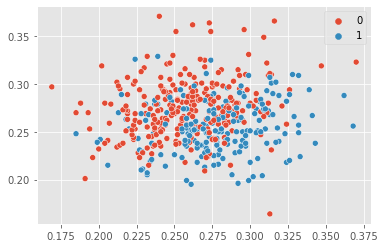

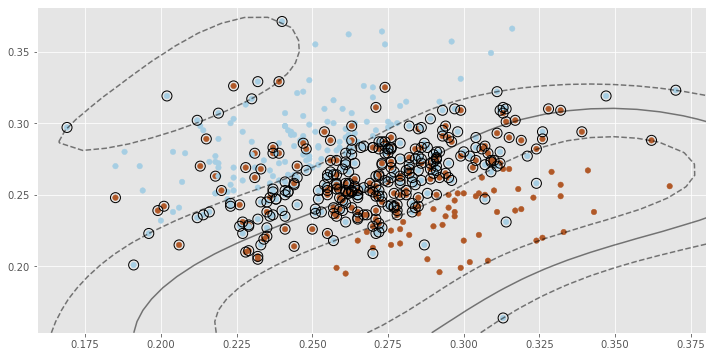

```
Score:
0.7151898734177216


Confusion matrix:
[[67 17]
 [28 46]]

None
```

```python
category = 'b_AVGr'
model_AVG = train_model(data, category)
```

```python
test_model(data_2021, category, model_AVG)
```

```
Stacked and filtered dataset:
             value        won_week
matchup_id      A      H        A  H
matchup
2021_02_00  0.250  0.201        1  0
2021_02_01  0.253  0.294        1  0
2021_02_02  0.242  0.230        1  0
2021_02_03  0.222  0.254        0  1
2021_02_04  0.250  0.263        1  0
...           ...    ...      ... ..
2021_13_02  0.283  0.255        1  0
2021_13_03  0.260  0.282        0  1
2021_13_04  0.263  0.257        1  0
2021_13_05  0.250  0.263        1  0
2021_13_06  0.252  0.260        0  1

[84 rows x 4 columns]


Score:
0.7142857142857143


Confusion matrix:
[[39  6]
 [18 21]]
```

##### OBP

```
Stacked and filtered dataset:
             value        won_week
matchup_id      A      H        A  H
matchup
2016_01_00  0.373  0.351        1  0
2016_01_01  0.324  0.328        1  0
2016_01_02  0.325  0.366        0  1
2016_01_03  0.315  0.333        0  1
2016_01_04  0.371  0.353        0  1
...           ...    ...      ... ..
2019_23_03  0.301  0.341        0  1
2019_24_00  0.329  0.324        1  0
2019_24_01  0.323  0.316        1  0
2019_24_02  0.322  0.365        0  1
2019_24_03  0.319  0.359        0  1

[629 rows x 4 columns]

Fitting 6 folds for each of 84 candidates, totalling 504 fits
The best parameters are {'C': 1.0, 'gamma': 100.0} with a score of 0.77

Model:
SVC(gamma=100.0)
```

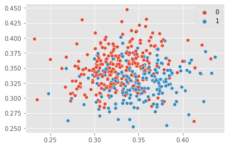

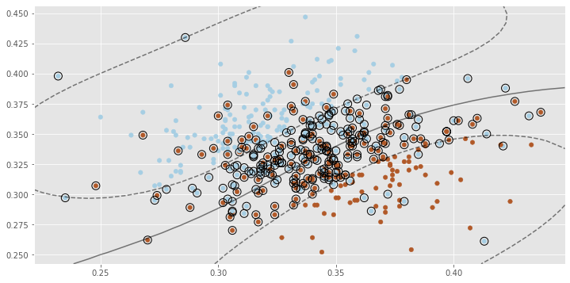

```
Score:
0.6835443037974683


Confusion matrix:
[[66 18]
 [32 42]]

None
```

```python
category = 'b_OBPr'
model_OBP = train_model(data, category)
```

```python
test_model(data_2021, category, model_OBP)
```

```
Stacked and filtered dataset:
             value        won_week
matchup_id      A      H        A  H
matchup
2021_02_00  0.342  0.298        1  0
2021_02_01  0.353  0.375        1  0
2021_02_02  0.319  0.299        1  0
2021_02_03  0.302  0.342        0  1
2021_02_04  0.342  0.326        1  0
...           ...    ...      ... ..
2021_13_02  0.363  0.346        1  0
2021_13_03  0.359  0.341        0  1
2021_13_04  0.353  0.351        1  0
2021_13_05  0.323  0.332        1  0
2021_13_06  0.340  0.330        0  1

[84 rows x 4 columns]


Score:
0.6785714285714286


Confusion matrix:
[[32 13]
 [14 25]]
```

##### SLG

```
Stacked and filtered dataset:
             value        won_week
matchup_id      A      H        A  H
matchup
2016_01_00  0.447  0.473        1  0
2016_01_01  0.441  0.458        1  0
2016_01_02  0.403  0.584        0  1
2016_01_03  0.397  0.376        0  1
2016_01_04  0.491  0.479        0  1
...           ...    ...      ... ..
2019_23_03  0.355  0.401        0  1
2019_24_00  0.464  0.489        1  0
2019_24_01  0.440  0.335        1  0
2019_24_02  0.422  0.518        0  1
2019_24_03  0.394  0.441        0  1

[629 rows x 4 columns]

Fitting 6 folds for each of 84 candidates, totalling 504 fits
The best parameters are {'C': 100.0, 'gamma': 0.1} with a score of 0.72

Model:
SVC(C=100.0, gamma=0.1)
```

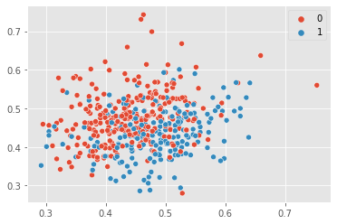

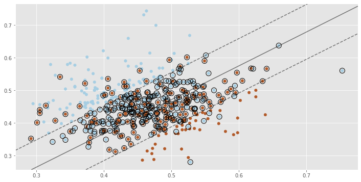

```
Score:
0.6708860759493671


Confusion matrix:
[[60 24]
 [28 46]]

None
```

```python
category = 'b_SLGr'
model_SLG = train_model(data, category)
```

```python
test_model(data_2021, category, model_SLG)
```

```
Stacked and filtered dataset:
             value        won_week
matchup_id      A      H        A  H
matchup
2021_02_00  0.405  0.306        1  0
2021_02_01  0.476  0.451        1  0
2021_02_02  0.421  0.340        1  0
2021_02_03  0.353  0.404        0  1
2021_02_04  0.442  0.473        1  0
...           ...    ...      ... ..
2021_13_02  0.533  0.424        1  0
2021_13_03  0.433  0.482        0  1
2021_13_04  0.404  0.411        1  0
2021_13_05  0.419  0.433        1  0
2021_13_06  0.380  0.533        0  1

[84 rows x 4 columns]


Score:
0.7142857142857143


Confusion matrix:
[[38  7]
 [17 22]]
```

##### HR

```
Stacked and filtered dataset:
            value       won_week
matchup_id     A     H        A  H
matchup
2016_01_00   5.0  11.0        1  0
2016_01_01  12.0  10.0        1  0
2016_01_02   9.0  18.0        0  1
2016_01_03   6.0   4.0        0  1
2016_01_04  11.0  11.0        0  1
...          ...   ...      ... ..
2019_23_03   7.0   6.0        0  1
2019_24_00   7.0  12.0        1  0
2019_24_01   8.0   4.0        1  0
2019_24_02   9.0   8.0        0  1
2019_24_03   7.0   9.0        0  1

[629 rows x 4 columns]

Fitting 6 folds for each of 84 candidates, totalling 504 fits
The best parameters are {'C': 0.1, 'gamma': 0.01} with a score of 0.64

Model:
SVC(C=0.1, gamma=0.01)
```

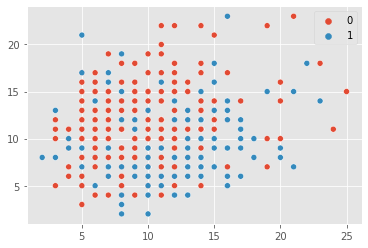

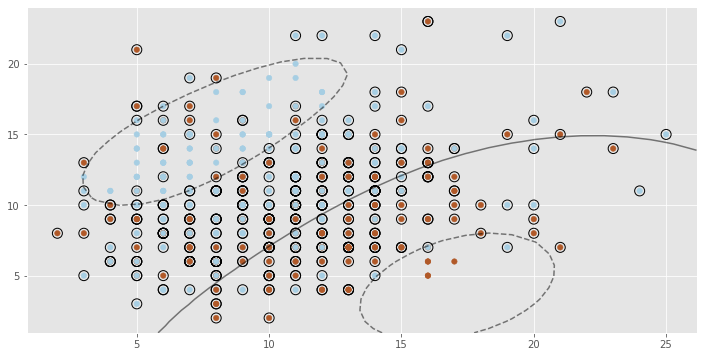

```
Score:
0.6139240506329114


Confusion matrix:
[[69 15]
 [46 28]]

None
```

```python
category = 'b_HR'
model_HR = train_model(data, category)
```

```python
test_model(data_2021, category, model_HR)
```

```
Stacked and filtered dataset:
            value       won_week
matchup_id     A     H        A  H
matchup
2021_02_00   8.0   5.0        1  0
2021_02_01  12.0   8.0        1  0
2021_02_02  10.0   4.0        1  0
2021_02_03   5.0   8.0        0  1
2021_02_04  11.0   7.0        1  0
...          ...   ...      ... ..
2021_13_02  16.0   7.0        1  0
2021_13_03   9.0  10.0        0  1
2021_13_04   6.0   7.0        1  0
2021_13_05  11.0   9.0        1  0
2021_13_06   5.0  17.0        0  1

[84 rows x 4 columns]


Score:
0.6904761904761905


Confusion matrix:
[[41  4]
 [22 17]]
```

##### WHIP

```
Stacked and filtered dataset:
            value       won_week
matchup_id     A     H        A  H
matchup
2016_01_00  1.13  1.34        1  0
2016_01_01  1.36  1.42        1  0
2016_01_02  1.27  0.79        0  1
2016_01_03  1.46  1.26        0  1
2016_01_04  1.33  1.12        0  1
...          ...   ...      ... ..
2019_23_03  0.91  1.34        0  1
2019_24_00  1.08  1.21        1  0
2019_24_01  0.97  1.09        1  0
2019_24_02  1.19  1.13        0  1
2019_24_03  1.23  1.26        0  1

[629 rows x 4 columns]

Fitting 6 folds for each of 84 candidates, totalling 504 fits
The best parameters are {'C': 10000.0, 'gamma': 0.0001} with a score of 0.68

Model:
SVC(C=10000.0, gamma=0.0001)
```

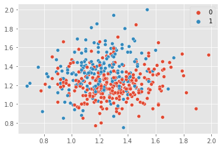

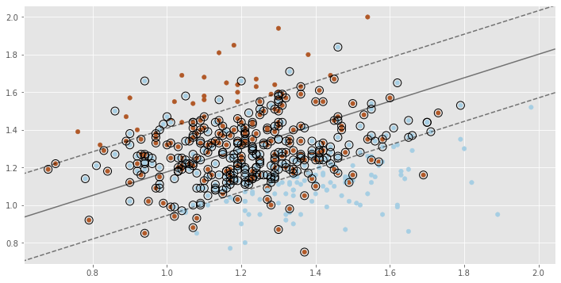

```
Score:
0.6518987341772152


Confusion matrix:
[[66 18]
 [37 37]]

None
```

```python
category = 'p_WHIPr'
model_WHIP = train_model(data, category)
```

```python
test_model(data_2021, category, model_WHIP)
```

```
Stacked and filtered dataset:
            value       won_week
matchup_id     A     H        A  H
matchup
2021_02_00  1.06  1.15        1  0
2021_02_01  1.08  1.13        1  0
2021_02_02  1.07  1.63        1  0
2021_02_03  1.03  0.92        0  1
2021_02_04  1.12  1.25        1  0
...          ...   ...      ... ..
2021_13_02  1.59  1.28        1  0
2021_13_03  1.35  1.20        0  1
2021_13_04  1.03  1.33        1  0
2021_13_05  1.25  1.26        1  0
2021_13_06  1.45  0.96        0  1

[84 rows x 4 columns]


Score:
0.6190476190476191


Confusion matrix:
[[38  7]
 [25 14]]
```

##### ERA

```
Stacked and filtered dataset:
            value       won_week
matchup_id     A     H        A  H
matchup
2016_01_00  2.95  4.29        1  0
2016_01_01  3.89  4.36        1  0
2016_01_02  2.90  2.79        0  1
2016_01_03  4.56  3.70        0  1
2016_01_04  2.73  3.63        0  1
...          ...   ...      ... ..
2019_23_03  1.65  4.37        0  1
2019_24_00  3.06  3.72        1  0
2019_24_01  3.41  3.51        1  0
2019_24_02  5.19  3.90        0  1
2019_24_03  3.28  3.24        0  1

[629 rows x 4 columns]

Fitting 6 folds for each of 84 candidates, totalling 504 fits
The best parameters are {'C': 1.0, 'gamma': 1.0} with a score of 0.67

Model:
SVC(gamma=1.0)
```

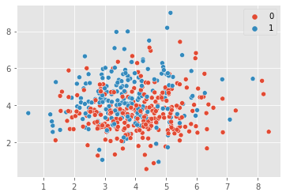

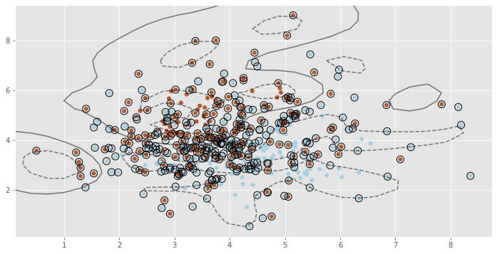

```
Score:
0.6835443037974683


Confusion matrix:
[[71 13]
 [37 37]]

None
```

```python
category = 'p_ERAr'
model_ERA = train_model(data, category)
```

```python
test_model(data_2021, category, model_ERA)
```

```
Stacked and filtered dataset:
            value       won_week
matchup_id     A     H        A  H
matchup
2021_02_00  3.51  3.23        1  0
2021_02_01  3.14  3.63        1  0
2021_02_02  2.56  7.79        1  0
2021_02_03  2.79  3.23        0  1
2021_02_04  3.68  3.12        1  0
...          ...   ...      ... ..
2021_13_02  6.44  4.79        1  0
2021_13_03  4.85  3.08        0  1
2021_13_04  3.05  5.85        1  0
2021_13_05  4.75  4.13        1  0
2021_13_06  4.82  3.72        0  1

[84 rows x 4 columns]


Score:
0.6428571428571429


Confusion matrix:
[[39  6]
 [24 15]]
```

##### QS

```
Stacked and filtered dataset:
            value      won_week
matchup_id     A    H        A  H
matchup
2016_01_00   4.0  4.0        1  0
2016_01_01   5.0  4.0        1  0
2016_01_02   4.0  5.0        0  1
2016_01_03   2.0  5.0        0  1
2016_01_04   3.0  5.0        0  1
...          ...  ...      ... ..
2019_23_03   2.0  2.0        0  1
2019_24_00   4.0  0.0        1  0
2019_24_01   3.0  3.0        1  0
2019_24_02   0.0  1.0        0  1
2019_24_03   6.0  6.0        0  1

[629 rows x 4 columns]

Fitting 6 folds for each of 84 candidates, totalling 504 fits
The best parameters are {'C': 100.0, 'gamma': 0.001} with a score of 0.70

Model:
SVC(C=100.0, gamma=0.001)
```

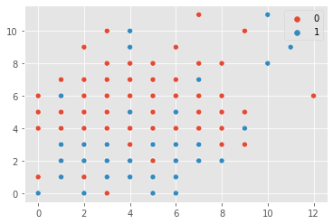

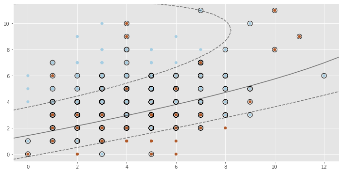

```
Score:
0.6329113924050633


Confusion matrix:
[[69 15]
 [43 31]]

None
```

```python
category = 'p_QS'
model_QS = train_model(data, category)
```

```python
test_model(data_2021, category, model_QS)
```

```
Stacked and filtered dataset:
            value      won_week
matchup_id     A    H        A  H
matchup
2021_02_00   4.0  1.0        1  0
2021_02_01   5.0  5.0        1  0
2021_02_02   3.0  0.0        1  0
2021_02_03   5.0  6.0        0  1
2021_02_04   3.0  2.0        1  0
...          ...  ...      ... ..
2021_13_02   3.0  5.0        1  0
2021_13_03   7.0  2.0        0  1
2021_13_04   5.0  1.0        1  0
2021_13_05   4.0  1.0        1  0
2021_13_06   4.0  3.0        0  1

[84 rows x 4 columns]


Score:
0.6428571428571429


Confusion matrix:
[[36  9]
 [21 18]]
```